# SARIMA Model for Inflation Rate

From the exploratory data analysis (EDA), it may be observed that the raw data for certain macroeconomic factors, such as interest rates or stock prices, is non-stationary and requires differencing to achieve stationarity. By differencing the data, we remove the trend and other non-stationary components, making it easier to model and forecast accurately.

#### Differentiated Time Series Plot

**Plot**

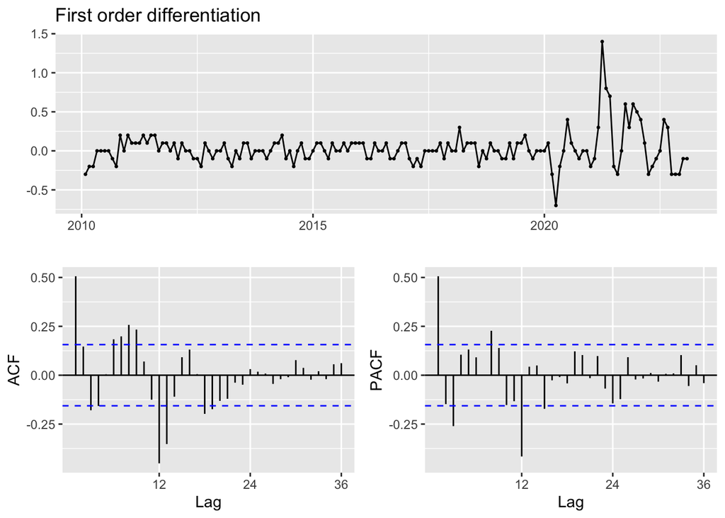

```r
#import the data
df <- read.csv("DATA/CLEANED DATA/inflation_rate_clean_data.csv")
#convert the data to time series data
myts <- ts(as.vector(t(as.matrix(df))), start=c(2010,1), end=c(2023,2), frequency=12)
#First order differentiation
df1 <- diff(myts)
# Plot
myts  %>% diff() %>% ggtsdisplay(main = "First order differentiation")
```

**ACF**

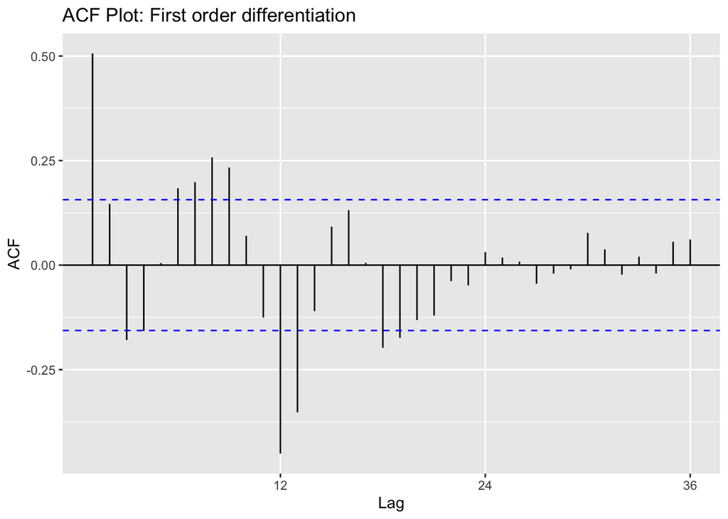

```r
#ACF plot
ggAcf(df1,36,main="ACF Plot: First order differentiation")
```

**PACF**

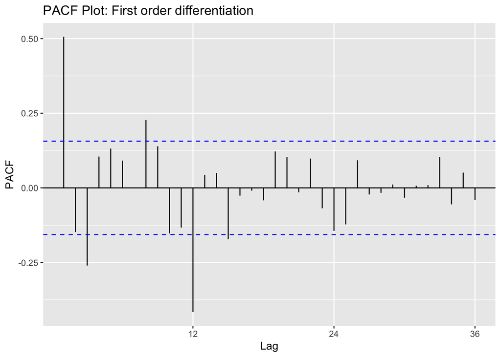

```r
ggPacf(df1,36,main="PACF Plot: First order differentiation")
```

**ADF Test**

```r
tseries::adf.test(df1)
```

```
    Augmented Dickey-Fuller Test

data:  df1
Dickey-Fuller = -3.8576, Lag order = 5, p-value = 0.01802
alternative hypothesis: stationary
```

**Seasonal ACF Plot**

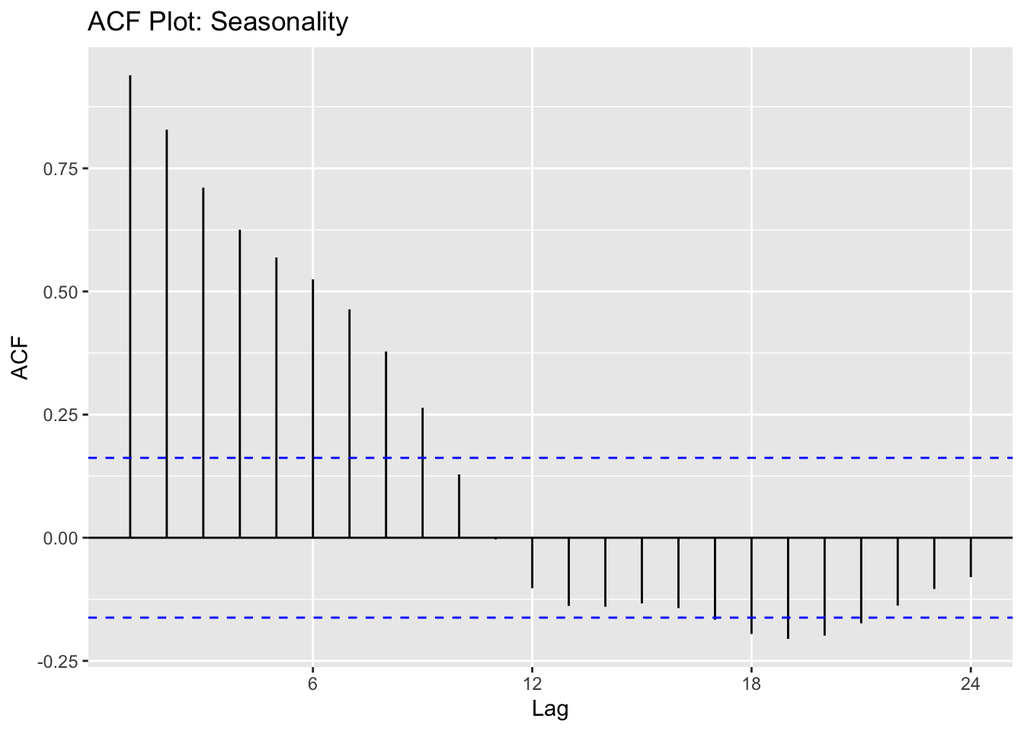

```r
# Seasonal differencing (period = 12)
df1_seasonal = myts %>%diff(differences = 1, lag = 12)
ggAcf(df1_seasonal,main="ACF Plot: Seasonality")
```

**Seasonal PACF Ploy**

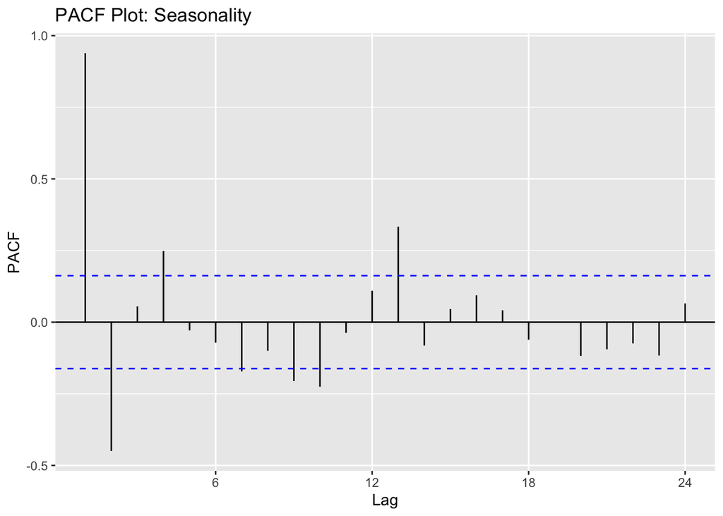

```r
# Seasonal differencing (period = 12)
ggPacf(df1_seasonal,main="PACF Plot: Seasonality")
```

After analyzing the ACF and PACF plots, it can be observed that most of the bar lines lie between the blue lines, indicating that the time series is stationary. This has been further confirmed through an Augmented Dickey-Fuller test as the p-value is less than 0.05. Once the data is stationary and there is presence of seasonality, the next step is to model it using SARIMA. The combination of ACF and PACF plots can help determine the appropriate values for p, d, and q in the ARIMA model. The order of differencing required to achieve stationarity gives the d value. The p value is determined by examining significant spikes at various lags in the PACF plot, while the q value is determined through significant spikes in the ACF plot. P and Q are determined similarly, from seasonal plot.

Here the parameters are d = 1, p = 0,1 (PACF Plot), q = 0,1 (ACF Plot), P = 1,2 (PACF Seasonality Plot), Q = 1,2,3,4 (ACF Seasonality Plot) D = 1

#### Model Selection

**SARIMA Result**

```r
######################## Check for different combinations ########


#write a funtion
SARIMA.c=function(p1,q1,P1,P2,Q1,Q2,data){

  #K=(p2+1)*(q2+1)*(P2+1)*(Q2+1)

  temp=c()
  d=1
  D=1
  s=12

  i=1
  temp= data.frame()
  ls=matrix(rep(NA,9*3),nrow=3)


  for (p in p1)
  {
    for(q in q1)
    {
      for(P in P1:P2)
      {
        for(Q in Q1:Q2)
        {
          if(p+d+q+P+D+Q<=9)
          {

            model<- Arima(data,order=c(p-1,d,q-1),seasonal=c(P-1,D,Q-1))
            ls[i,]= c(p-1,d,q-1,P-1,D,Q-1,model$aic,model$bic,model$aicc)
            i=i+1
            #print(i)

          }

        }
      }
    }

  }


  temp= as.data.frame(ls)
  names(temp)= c("p","d","q","P","D","Q","AIC","BIC","AICc")

  temp

}
# q=0,1,; Q=0,1,2,3 and PACF plot: p=0,1; P=0,1,2, D=1 and d=1
output=SARIMA.c(p1=2,q1=2,P1=1,P2=3,Q1=1,Q2=3,data=myts)
#output
knitr::kable(output)
```

| p | d | q | P | D | Q | AIC | BIC | AICc |
| --- | --- | --- | --- | --- | --- | --- | --- | --- |
| 1 | 1 | 1 | 0 | 1 | 0 | 86.02072 | 94.950919 | 86.19093 |
| 1 | 1 | 1 | 0 | 1 | 1 | -26.80019 | -14.893256 | -26.51448 |
| 1 | 1 | 1 | 1 | 1 | 0 | -16.22925 | -4.322316 | -15.94354 |

**Auto Arima Model**

```r
auto.arima(myts)
```

```
Series: myts
ARIMA(4,1,1)(0,0,1)[12] with drift

Coefficients:
         ar1      ar2      ar3     ar4      ma1     sma1   drift
      1.1757  -0.2352  -0.3924  0.3603  -0.6966  -0.5922  0.0215
s.e.  0.1166   0.1251   0.1162  0.0757   0.1037   0.0807  0.0173

sigma^2 = 0.02376:  log likelihood = 71.61
AIC=-127.23   AICc=-126.25   BIC=-102.78
```

Since there are different models to choose from, it is important to perform model diagnostics to determine the best model for the data. These diagnostics can include checking for residual normality, checking for autocorrelation and partial autocorrelation in the residuals, and comparing the forecasted values to the actual values. By conducting these tests, we can determine which model provides the best fit for the data and is therefore the most appropriate to use for forecasting future values.

#### Model Diagnostic

**Model 1 Plot**

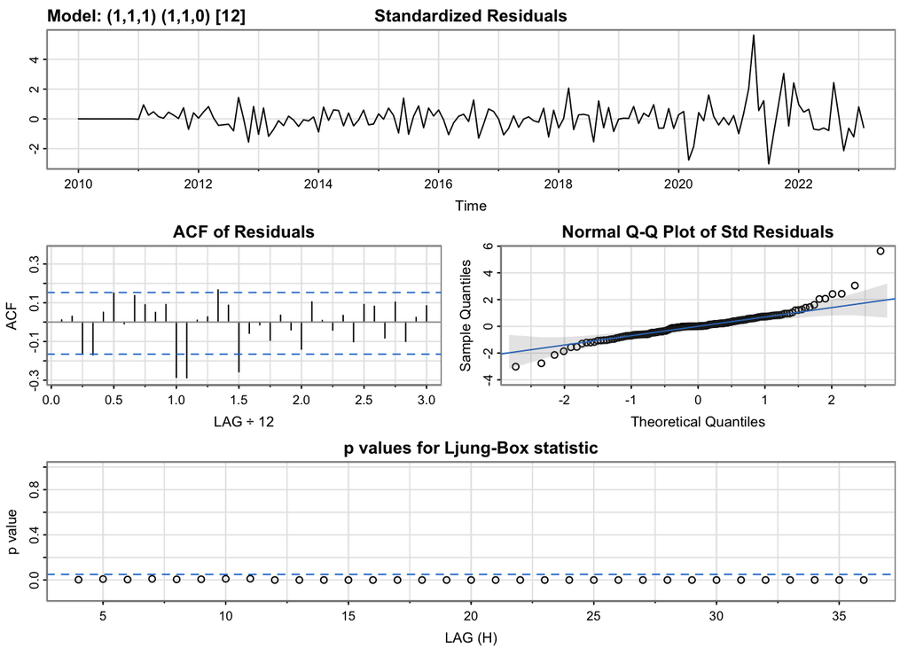

```r
model_output <- capture.output(sarima(myts, 1,1,1,1,1,0,12))
```

**Model 1**

```r
cat(model_output[22:52], model_output[length(model_output)], sep = "\n")
```

```
$fit

Call:
arima(x = xdata, order = c(p, d, q), seasonal = list(order = c(P, D, Q), period = S),
    include.mean = !no.constant, transform.pars = trans, fixed = fixed, optim.control = list(trace = trc,
        REPORT = 1, reltol = tol))

Coefficients:
         ar1     ma1     sar1
      0.3616  0.2288  -0.8036
s.e.  0.1242  0.1212   0.0530

sigma^2 estimated as 0.04535:  log likelihood = 12.11,  aic = -16.23

$degrees_of_freedom
[1] 142

$ttable
     Estimate     SE  t.value p.value
ar1    0.3616 0.1242   2.9123  0.0042
ma1    0.2288 0.1212   1.8883  0.0610
sar1  -0.8036 0.0530 -15.1732  0.0000

$AIC
[1] -0.1119259
```

**Model 2 Plot**

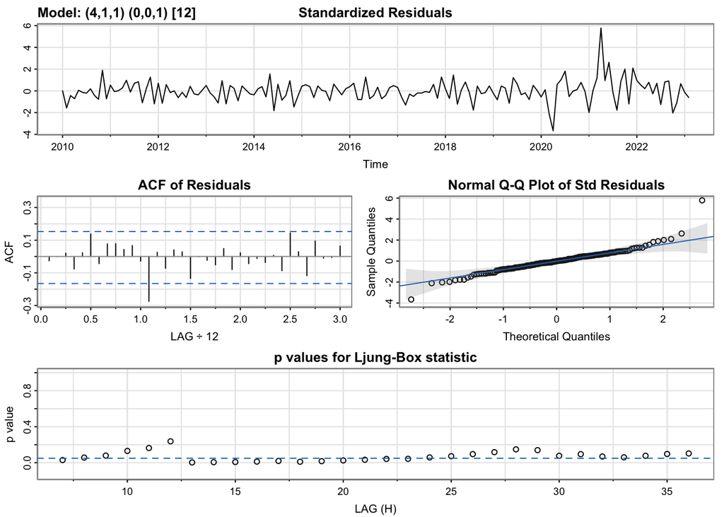

```r
model_output <- capture.output(sarima(myts, 4,1,1,0,0,1,12))
```

**Model 2**

```r
cat(model_output[46:81], model_output[length(model_output)], sep = "\n")
```

```
$fit

Call:
arima(x = xdata, order = c(p, d, q), seasonal = list(order = c(P, D, Q), period = S),
    xreg = constant, transform.pars = trans, fixed = fixed, optim.control = list(trace = trc,
        REPORT = 1, reltol = tol))

Coefficients:
         ar1      ar2      ar3     ar4      ma1     sma1  constant
      1.1757  -0.2352  -0.3924  0.3603  -0.6966  -0.5922    0.0215
s.e.  0.1166   0.1251   0.1162  0.0757   0.1037   0.0807    0.0173

sigma^2 estimated as 0.0227:  log likelihood = 71.61,  aic = -127.23

$degrees_of_freedom
[1] 150

$ttable
         Estimate     SE t.value p.value
ar1        1.1757 0.1166 10.0868  0.0000
ar2       -0.2352 0.1251 -1.8803  0.0620
ar3       -0.3924 0.1162 -3.3768  0.0009
ar4        0.3603 0.0757  4.7621  0.0000
ma1       -0.6966 0.1037 -6.7199  0.0000
sma1      -0.5922 0.0807 -7.3380  0.0000
constant   0.0215 0.0173  1.2380  0.2177

$AIC
[1] -0.8103599

$AICc
[1] -0.8055721

$BIC
[1] -0.6546276
```

The equation for this model:
$$\Delta Y_t = \phi_1 \Delta Y_{t-1} + \phi_2 \Delta Y_{t-2} + \phi_3 \Delta Y_{t-3} + \phi_4 \Delta Y_{t-4} + \theta_1 \epsilon_{t-1} + \epsilon_t + \theta_{12} \epsilon_{t-12}$$

#### Forcast

**Short Term Forcast**

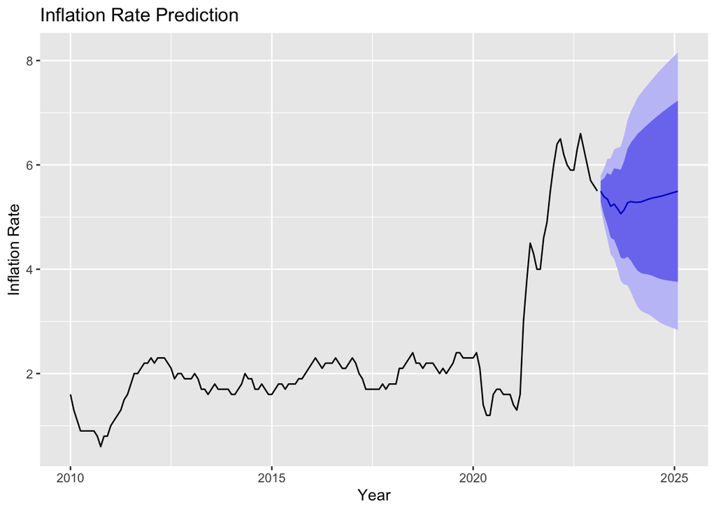

```r
myts %>%
  Arima(order=c(4,1,1),seasonal = c(0,0,1),include.drift = TRUE) %>%
  forecast %>%
  autoplot(main = "Inflation Rate Prediction") +
  ylab("Inflation Rate") + xlab("Year")
```

**Long term Forcast**

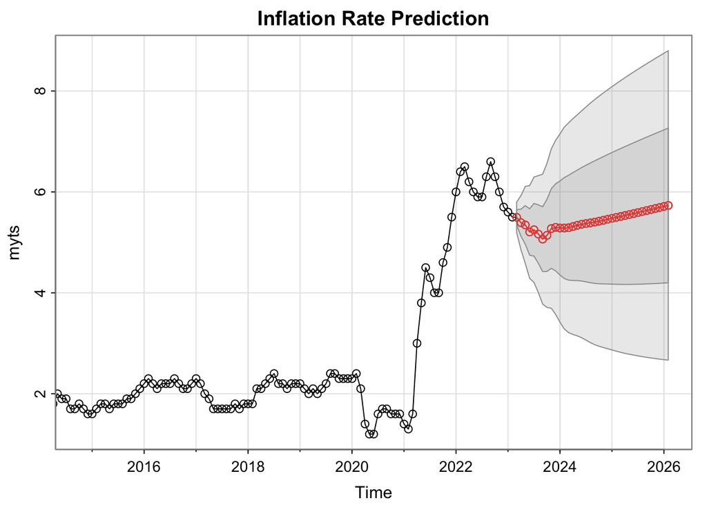

```
$pred
          Jan      Feb      Mar      Apr      May      Jun      Jul      Aug
2023                   5.495776 5.389748 5.344802 5.205688 5.249631 5.164470
2024 5.283954 5.283987 5.290514 5.314089 5.337350 5.358570 5.373114 5.386553
2025 5.476534 5.494819 5.513071 5.531901 5.551331 5.571139 5.591010 5.610839
2026 5.711529 5.732022
          Sep      Oct      Nov      Dec
2023 5.064247 5.138831 5.273497 5.297473
2024 5.400955 5.418630 5.437955 5.457675
2025 5.630673 5.650633 5.670779 5.691099
2026

$se
           Jan       Feb       Mar       Apr       May       Jun       Jul
2023                     0.1506640 0.2690050 0.3827598 0.4595446 0.5219644
2024 0.9329297 1.0004244 1.0394805 1.0695190 1.0948899 1.1240493 1.1549882
2025 1.3042817 1.3255537 1.3460871 1.3656904 1.3844121 1.4024993 1.4201440
2026 1.5180451 1.5331652
           Aug       Sep       Oct       Nov       Dec
2023 0.5789069 0.6431488 0.7142951 0.7894332 0.8627722
2024 1.1860724 1.2138042 1.2384755 1.2609465 1.2827317
2025 1.4374323 1.4543438 1.4708448 1.4869326 1.5026483
2026
```

```r
sarima.for(myts,36, 4,1,1,0,0,1,12, main = "Inflation Rate Prediction")
```

The two figures above show an idea of the short term and the long-term forecasted Inflation Rate. The forecasted values is be based on the estimated parameters of the model, which were obtained by fitting it to the historical data. One way to assess the accuracy of the forecasts is to use cross-validation, which involves splitting the data into training and testing sets and comparing the predicted values to the actual values in the test set. This can help to identify any potential problems with the model and to fine-tune the model parameters.

**12 Step ahead Cross Validation**

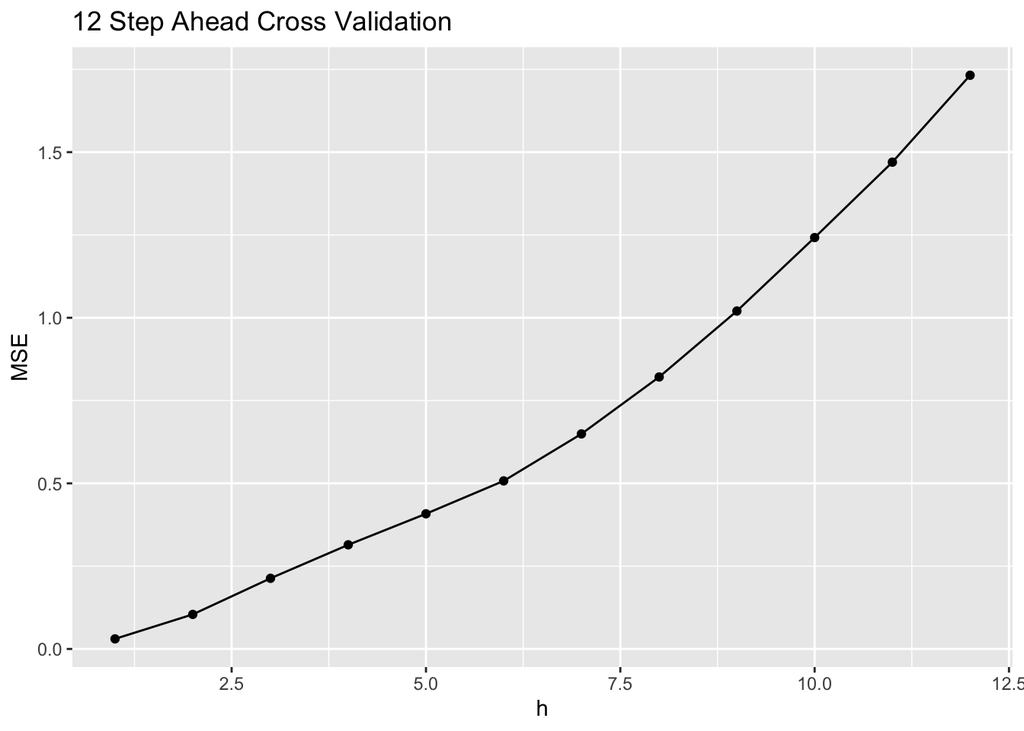

```r
#a seasonal cross validation using 12 steps ahead forecasts
farima1 <- function(x, h){forecast(Arima(x, order=c(4,1,1),seasonal = c(0,0,1)), h=h)}

# Compute cross-validated errors for up to 12 steps ahead
e <- tsCV(myts, forecastfunction = farima1, h = 12)

# Compute the MSE values and remove missing values
mse <- colMeans(e^2, na.rm = TRUE)

# Plot the MSE values against the forecast horizon
data.frame(h = 1:12, MSE = mse) %>%
  ggplot(aes(x = h, y = MSE)) + geom_point()+geom_line()+ggtitle("12 Step Ahead Cross Validation")
```

**1 Step ahead Cross Validation**

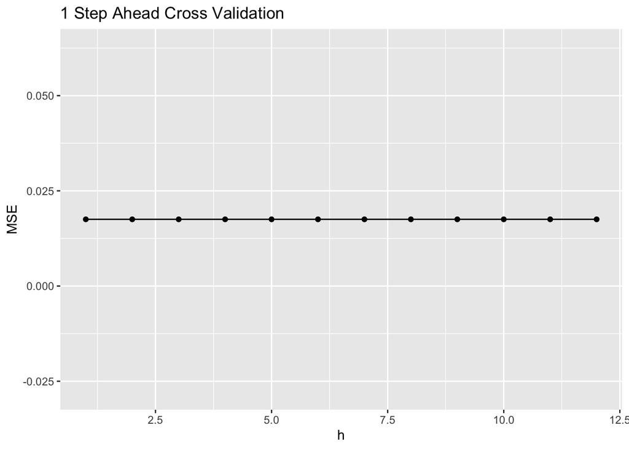

```r
#a seasonal cross validation using 1 steps ahead forecasts
farima1 <- function(x, h){forecast(Arima(x, order=c(4,1,1),seasonal = c(0,0,1)),h=h)}

# Compute cross-validated errors for up to 1 steps ahead
e <- tsCV(myts, forecastfunction = farima1, h = 1)
mse <-abs(mean(e,na.rm=TRUE))

# Plot the MSE values against the forecast horizon
data.frame(h = 1:12, MSE = mse) %>%
  ggplot(aes(x = h, y = MSE)) + geom_point()+geom_line()+ggtitle("1 Step Ahead Cross Validation")
```

#### Model Comparison

**Plot**

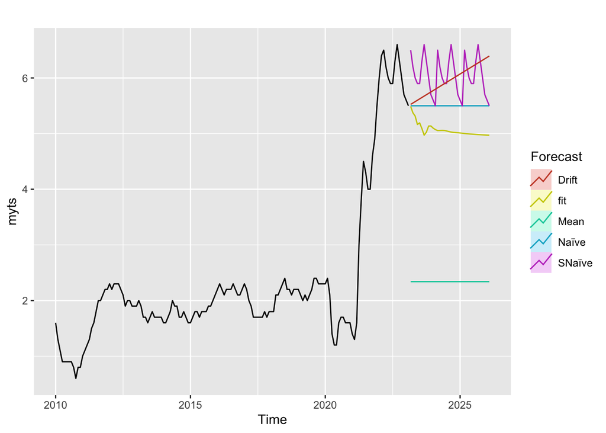

```r
fit <- Arima(myts, order=c(4,1,1),seasonal = c(0,0,1))
autoplot(myts) +
  autolayer(meanf(myts, h=36),
            series="Mean", PI=FALSE) +
  autolayer(naive(myts, h=36),
            series="Naïve", PI=FALSE) +
  autolayer(snaive(myts, h=36),
            series="SNaïve", PI=FALSE)+
  autolayer(rwf(myts, h=36, drift=TRUE),
            series="Drift", PI=FALSE)+
  autolayer(forecast(fit,36),
            series="fit",PI=FALSE) +
  guides(colour=guide_legend(title="Forecast"))
```

**Model Error Table**

```r
summary <- summary(fit)
snaive <- snaive(myts, h=36)
#accuracy(snaive)
```

| Error | Model | Snavie |
| --- | --- | --- |
| ME | 0.01203582 | 0.4178082 |
| RMSE | 0.1508245 | 1.215031 |
| MAE | 0.1068308 | 0.7410959 |
| MPE | 0.3265318 | 6.891819 |
| MAPE | 5.342487 | 26.54941 |
| MASE | 0.1441525 | 1.0000000 |
| ACF1 | -0.0333594 | 0.9389579 |